# Tugas-Pertemuan-4

Elardian Putera Ramadhan (G1401231042)

2025-09-24

## *Packages*

```r
# Install library jika belum ada
# install.packages("TSA")

# Muat library
library(TSA)
```

## **Proses MA(2)**

Proses MA(2) dapat dituliskan sebagai berikut:

$$Y_t = e_t - \theta_1e_{t-1} -
\theta_2e_{t-2}$$

Akan dibangkitkan proses MA(2) dengan $\theta_1$ = 0.4 dan $\theta_2$ = 0.6 sebanyak 300 data.

### **Pembangkitan Data MA(2)**

Pertama, bangkitkan *white noise* sebagai dasar. Karena proses MA(2) memerlukan $e_{t−1}$ dan $e_{t−2}$, maka perlu membangkitkan *white noise* sedikit lebih banyak dari 300.

```r
# Menentukan parameter
n <- 300
theta1 <- 0.4
theta2 <- 0.6
set.seed(1234) # Untuk hasil yang konsisten

# Bangkitkan white noise
wn <- rnorm(n + 2)
```

#### **1. Pembangkitan Manual**

Nilai-nilai data dibangkitkan menggunakan loop sesuai rumus MA(2).

```r
# Siapkan vektor kosong untuk menampung hasil
ma2_manual <- numeric(n)

# Loop untuk membangkitkan data
for(i in 3:(n+2)){
  ma2_manual[i-2] <- wn[i] + theta1 * wn[i-1] + theta2 * wn[i-2]
}

# Ubah menjadi objek time series
ma2_manual <- ts(ma2_manual)
ma2_manual
```

```
## Time Series:
## Start = 1
## End = 300
## Frequency = 1
##   [1]  0.471173424 -1.745463687  0.141510314 -0.729712854 -0.114842790
##   [6] -0.472894305 -1.127948717 -1.443797742 -1.171879031 -1.723286222
##  [11] -1.461924092 -0.845074607  0.519525249  0.312187420  0.020572732
##  [16] -1.181770516 -1.508255550  1.534249256  0.598119283  1.012450498
##  [21] -0.556369299 -0.011041246 -0.774213194 -1.449939345 -0.420758391
##  [26] -1.662676381 -0.079747157 -1.556197355  0.718835126 -0.596243221
##  [31] -0.238298741 -1.070389923 -2.255260716 -2.120011486 -3.624543435
##  [36] -2.913580609 -2.138714925 -1.388210999  1.086560934 -0.768382742
##  [41] -0.413123964 -1.263954490 -1.619808057 -1.534624150 -2.091327966
##  [46] -2.276021753 -1.689013389 -1.457572736 -2.319068111 -1.602598402
##  [51] -2.425338748 -1.807763414 -1.233628102 -0.110845196  1.775654086
```

[output cut: 49 more lines]

#### **2. Pembangkitan dengan `arima.sim`**

Cara yang lebih praktis adalah menggunakan fungsi `arima.sim()`

```r
set.seed(1234) # Gunakan seed yang sama untuk perbandingan
ma2_sim <- arima.sim(model = list(order = c(0, 0, 2), ma = c(theta1, theta2)), n = n)
ma2_sim
```

```
## Time Series:
## Start = 1
## End = 300
## Frequency = 1
##   [1]  0.471173424 -1.745463687  0.141510314 -0.729712854 -0.114842790
##   [6] -0.472894305 -1.127948717 -1.443797742 -1.171879031 -1.723286222
##  [11] -1.461924092 -0.845074607  0.519525249  0.312187420  0.020572732
##  [16] -1.181770516 -1.508255550  1.534249256  0.598119283  1.012450498
##  [21] -0.556369299 -0.011041246 -0.774213194 -1.449939345 -0.420758391
##  [26] -1.662676381 -0.079747157 -1.556197355  0.718835126 -0.596243221
##  [31] -0.238298741 -1.070389923 -2.255260716 -2.120011486 -3.624543435
##  [36] -2.913580609 -2.138714925 -1.388210999  1.086560934 -0.768382742
##  [41] -0.413123964 -1.263954490 -1.619808057 -1.534624150 -2.091327966
##  [46] -2.276021753 -1.689013389 -1.457572736 -2.319068111 -1.602598402
##  [51] -2.425338748 -1.807763414 -1.233628102 -0.110845196  1.775654086
```

[output cut: 49 more lines]

### **Karakteristik MA(2)**

#### **1. Plot Time Series**

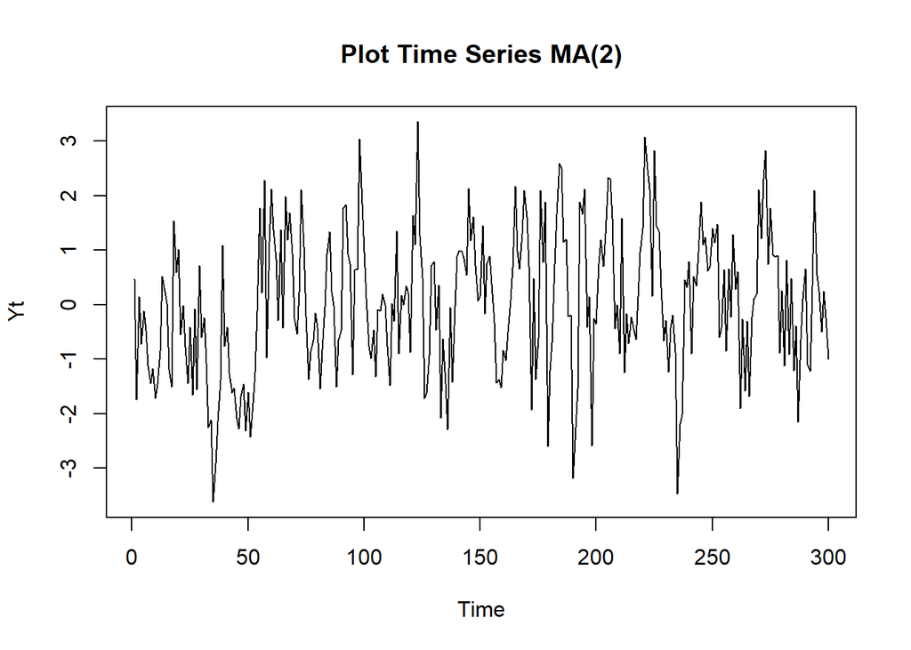

```r
ts.plot(ma2_manual, main = "Plot Time Series MA(2)", ylab = "Yt")
```

Berdasarkan plot, data terlihat **stasioner** karena bergerak di sekitar rataan yang konstan (sekitar 0) dengan ragam yang juga konstan.

#### **2. Plot ACF, PACF, dan EACF**

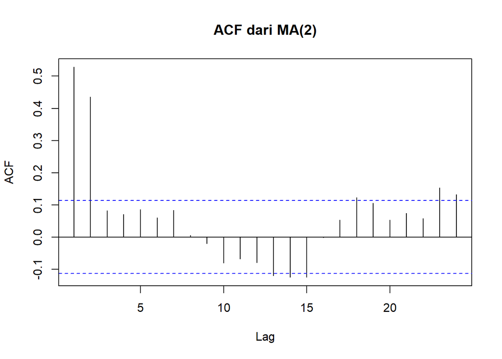

```r
# Plot ACF
acf(ma2_manual, main="ACF dari MA(2)")
```

Berdasarkan plot ACF tersebut, terlihat bahwa plot ACF *cuts off* di lag kedua

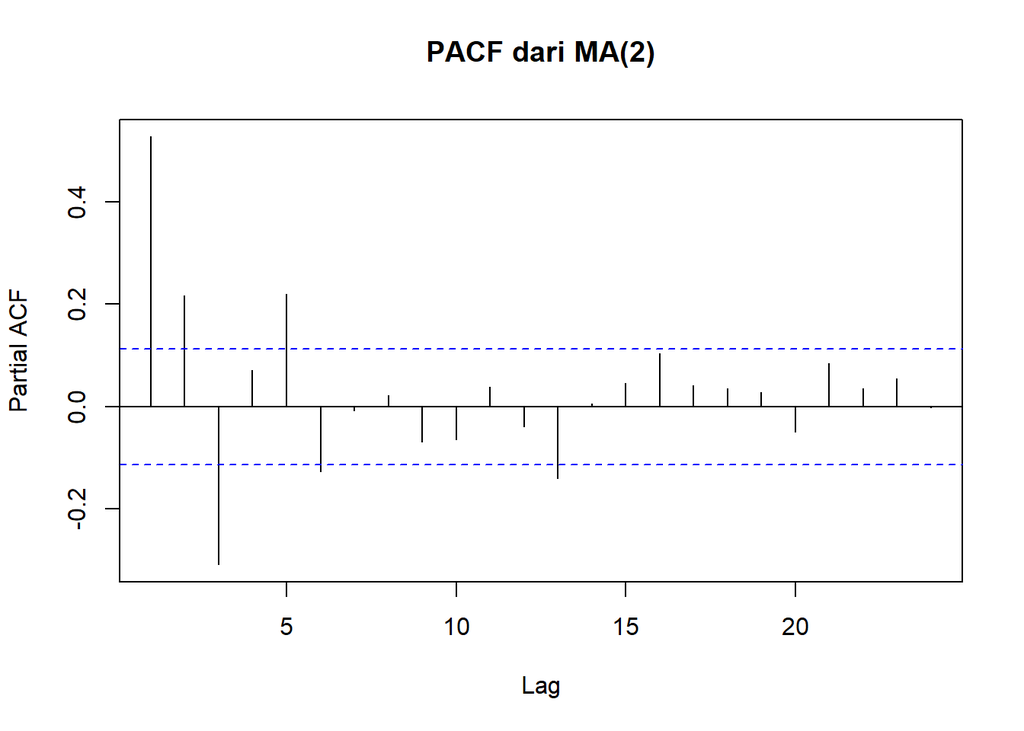

```r
# Plot PACF
pacf(ma2_manual, main="PACF dari MA(2)")
```

Berdasarkan plot PACF tersebut, terlihat bahwa plot PACF cenderung *tails off* dan membentuk gelombang sinus.

```r
# Plot EACF
eacf(ma2_manual)
```

```
## AR/MA
##   0 1 2 3 4 5 6 7 8 9 10 11 12 13
## 0 x x o o o o o o o o o  o  x  x
## 1 x x x o o o o o o o o  o  o  o
## 2 x x x x o o o o o o o  o  o  o
## 3 x x x x o o o o o o o  o  o  o
## 4 x x x x o o o o o o o  o  o  o
## 5 x x o x x o x o o o o  o  o  o
## 6 o x o o x o o x o o o  o  o  o
## 7 x o x o x o o x o o o  o  o  o
```

Berdasarkan pola segitiga nol pada plot EACF, terlihat bahwa segitiga nol berada pada ordo AR(0) dan ordo MA(2)

#### **3. *Scatterplot* Antar Lag**

Untuk membuat *scatterplot*, perlu dibuat vektor data yang sudah digeser (lag).

##### **Korelasi antara** $Y_t$ **dengan** $Y_{t-1}$

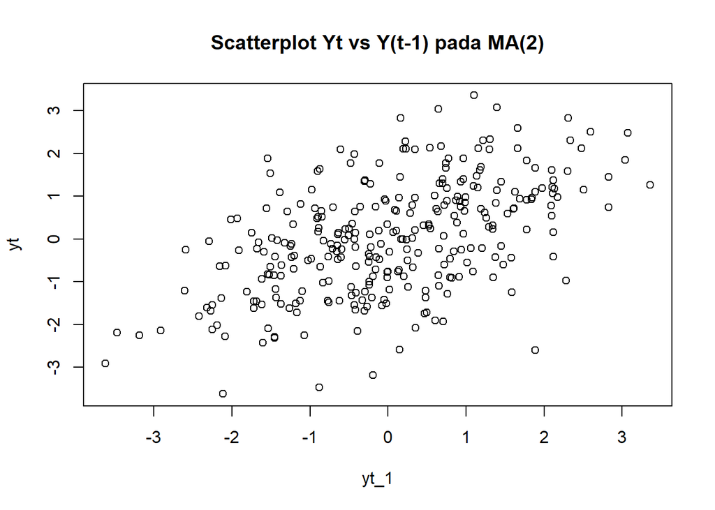

```r
# Yt
yt <- ma2_manual[-1]
# Yt-1
yt_1 <- ma2_manual[-n]

plot(y=yt, x=yt_1, main="Scatterplot Yt vs Y(t-1) pada MA(2)")
```

```r
cor(yt, yt_1)
```

```
## [1] 0.5285939
```

Nilai korelasi dari simulasi ini kita bandingkan dengan perhitungan teoritisnya:

$$\rho_1 = \frac{-\theta_1 + \theta_1\theta_2}{1 + \theta_1^2 +
\theta_2^2} = \frac{-(-0.4) + (-0.4)⋅(-0.6)}{1 + (-0.4)^2 + (-0.6)^2} =
\frac{0.64}{1.52} \approx 0.421$$